# Visualisation with R (examples from The Book of R)

JV (a transcription of The Book of R chapters 14, 23)

# Basic visualisation with R

## Difference between base R graphics and ggplot2

With base R it is easier to exercise control over the details of a plot, while `ggplot2` is more powerful in the presentation of complex datasets where the separation of subsets by categorical variables needs to be shown. The `ggplot2` package is also better at producing quick graphs that look presentable enough.

**NOTE: In the following examples a data set available in R called `mtcars` is used.**

```r
head(mtcars)
```

```
##                    mpg cyl disp  hp drat    wt  qsec vs am gear carb
## Mazda RX4         21.0   6  160 110 3.90 2.620 16.46  0  1    4    4
## Mazda RX4 Wag     21.0   6  160 110 3.90 2.875 17.02  0  1    4    4
## Datsun 710        22.8   4  108  93 3.85 2.320 18.61  1  1    4    1
## Hornet 4 Drive    21.4   6  258 110 3.08 3.215 19.44  1  0    3    1
## Hornet Sportabout 18.7   8  360 175 3.15 3.440 17.02  0  0    3    2
## Valiant           18.1   6  225 105 2.76 3.460 20.22  1  0    3    1
```

## Barcharts

Barcharts are for nominal data.

### Barchart with base R

```r
cyl.freq<-table(mtcars$cyl)
cyl.freq
```

```
##
##  4  6  8
## 11  7 14
```

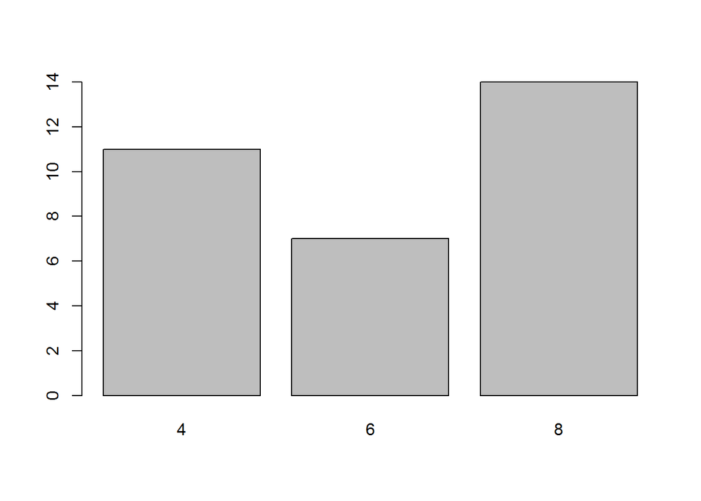

```r
barplot(cyl.freq)
```

### Dodged barchart with base R

```r
cyl.freq.matrix<-table(mtcars$am, mtcars$cyl)
cyl.freq.matrix
```

```
##
##      4  6  8
##   0  3  4 12
##   1  8  3  2
```

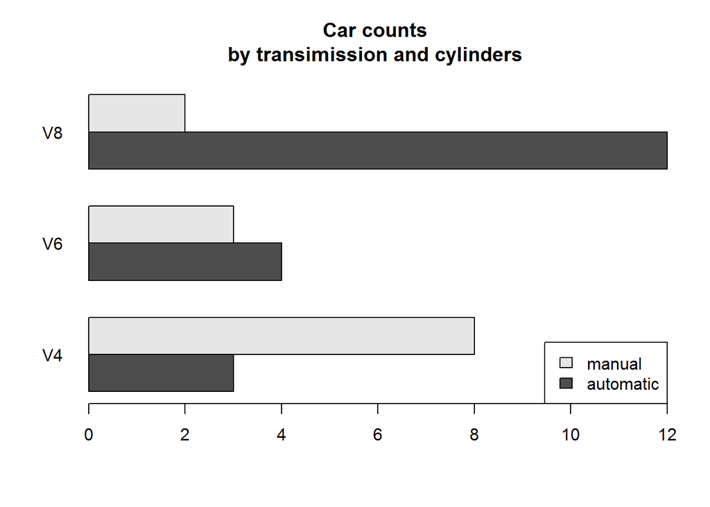

```r
barplot(cyl.freq.matrix, beside=TRUE, horiz=TRUE, las=1, main="Car counts\nby transimission and cylinders", names.arg=c("V4", "V6", "V8"), legend.text=c("automatic", "manual"), args.legend=list(x="bottomright"))
```

### Barchart with ggplot2

**NOTE:** for qplot data type must be a factor

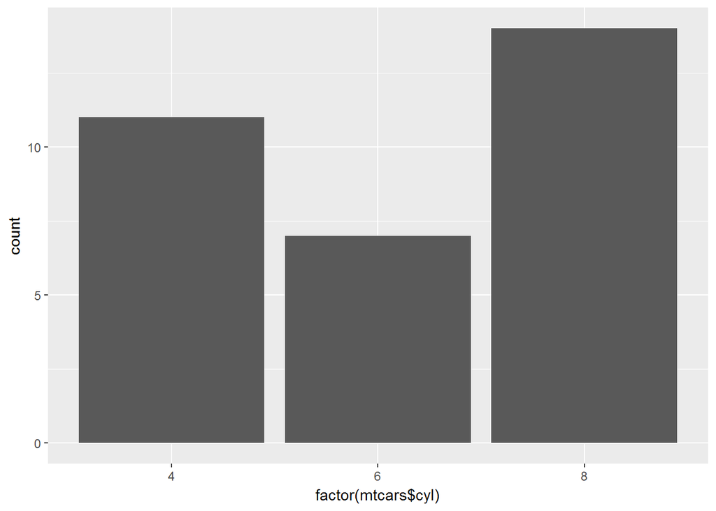

```r
library("ggplot2")
qplot(factor(mtcars$cyl), geom="bar")
```

### Dodged barchart with ggplot2

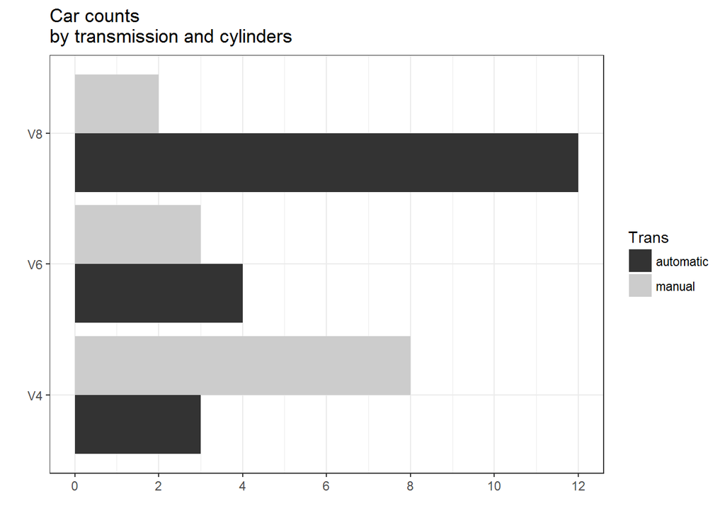

```r
qplot(factor(mtcars$cyl), geom="blank", fill=factor(mtcars$am), xlab="", ylab="", main="Car counts\nby transmission and cylinders") +
   geom_bar(position="dodge") +
   scale_x_discrete(labels=c("V4", "V6", "V8")) +
   scale_y_continuous(breaks=seq(0, 12, 2)) +
   theme_bw() +
   coord_flip() +
   scale_fill_grey(name="Trans", labels=c("automatic", "manual"))
```

## Piecharts

These are not recommended (see the comment at the end of help for the function `pie()`) and related functions are scarce in R.

### Piechart with base R

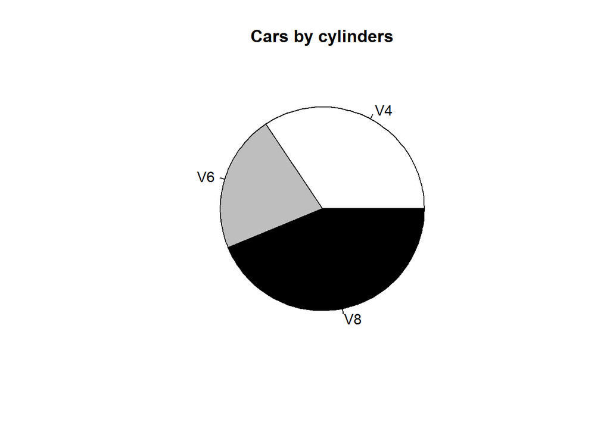

```r
pie(table(mtcars$cyl), labels=c("V4", "V6", "V8"), col=c("white", "gray", "black"), main="Cars by cylinders")
```

## Histograms

These look similar to barcharts but are used with continuous (or effectively so) data.

### Histogram with base R

We will plot a histogram for the gross horsepower variable in the `mtcars` dataset.

```r
mtcars$hp
```

```
##  [1] 110 110  93 110 175 105 245  62  95 123 123 180 180 180 205 215 230
## [18]  66  52  65  97 150 150 245 175  66  91 113 264 175 335 109
```

Notice that the histogram has a *right* or *positive* skew

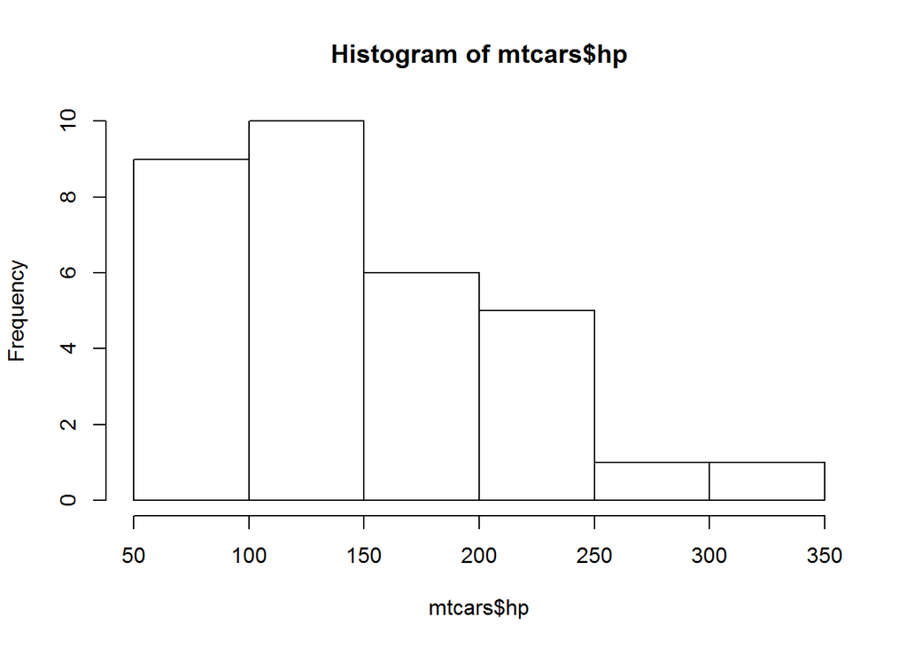

```r
hist(mtcars$hp)
```

Now we plot a histogram with more detail, including narrower intervals for binning the data.

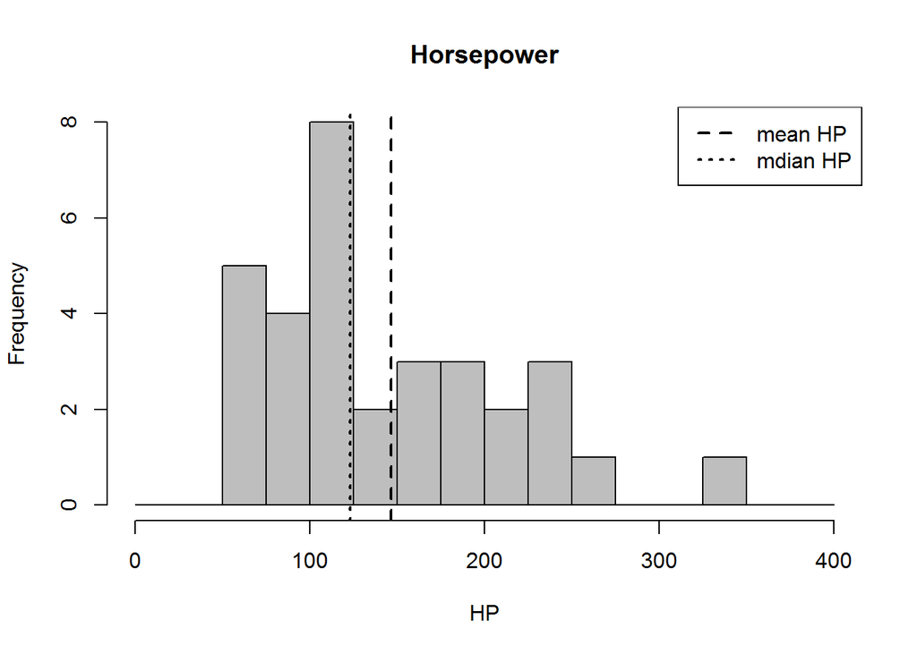

```r
hist(mtcars$hp, breaks=seq(0, 400, 25), col="gray", main="Horsepower", xlab="HP")
abline(v=c(mean(mtcars$hp), median(mtcars$hp)), lty=c(2, 3), lwd=2)
legend("topright", legend=c("mean HP", "mdian HP"), lty=c(2, 3), lwd=2)
```

Using a smaller bin width produces more detail in the histogram, but increases the risk of unimportant details being highlighted - the visualisation equivalent of model overfitting. There are algorithms that use the data itself to determine the best bin sizes. These are all implemented as part of `hist()` and can be specified using the `breaks` parameter, for example `breaks="Sturges"`.

### Histogram with ggplot2

Calling `qplot()` with a numeric vector as the only parameter plots a histogram by default.

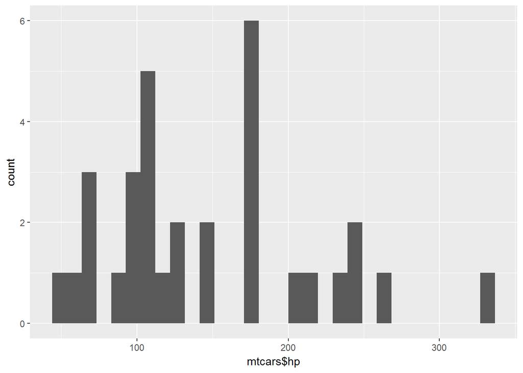

```r
qplot(mtcars$hp)
```

We can produce more detail in a histogram more representative of the data by using additional functions:

```r
qplot(mtcars$hp, geom="blank", main="Horsepower", xlab="HP") +
      geom_histogram(color="black", fill="white", breaks=seq(0, 400, 25), closed="right") +
      geom_vline(mapping=aes(xintercept=c(mean(mtcars$hp), median(mtcars$hp)), linetype=factor(c("mean", "median"))), show.legend=TRUE) +
      scale_linetype_manual(values=c(2, 3)) + labs(linetype="")
```

[output not shown]

**NOTE: In the following examples a data set available in R called `quakes` is used.**

```r
head(quakes)
```

```
##      lat   long depth mag stations
## 1 -20.42 181.62   562 4.8       41
## 2 -20.62 181.03   650 4.2       15
## 3 -26.00 184.10    42 5.4       43
## 4 -17.97 181.66   626 4.1       19
## 5 -20.42 181.96   649 4.0       11
## 6 -19.68 184.31   195 4.0       12
```

## Boxplots

### Boxplot vs. Histogram

Let’s start by comparing a histogram with a boxplot.

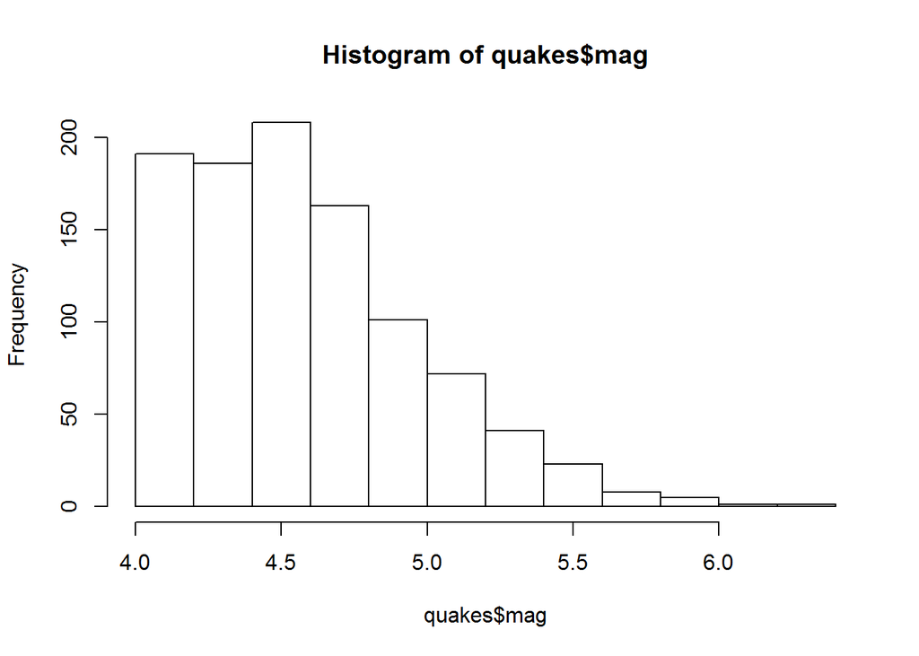

```r
hist(quakes$mag)
```

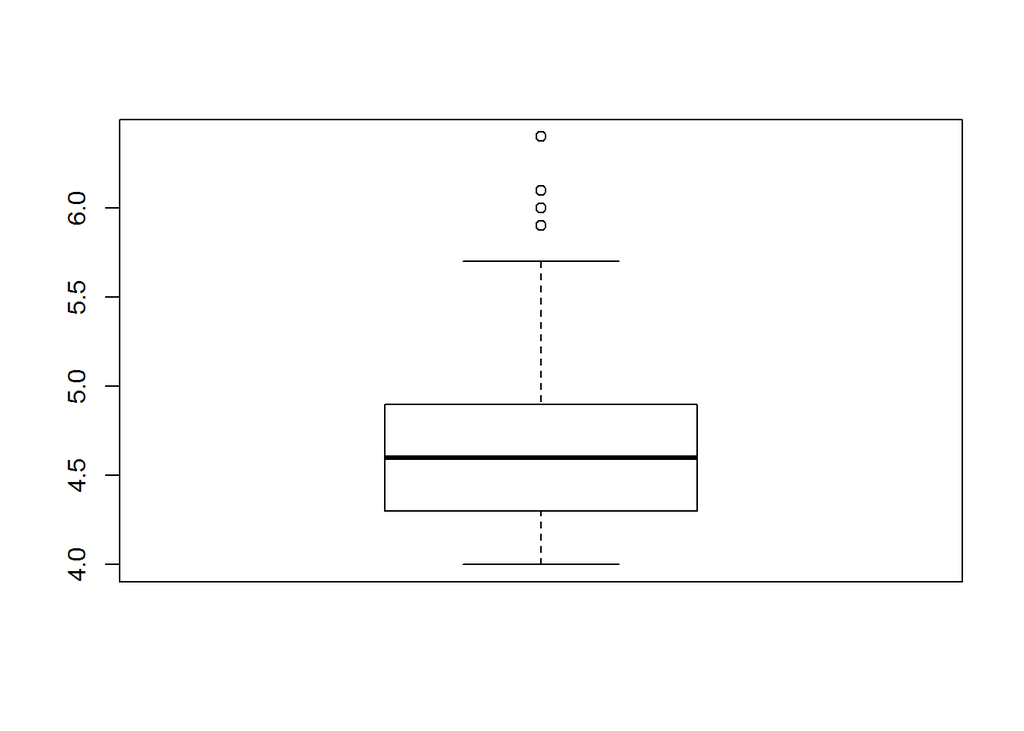

```r
boxplot(quakes$mag)
```

The default method for identifying outliers is to mark as such any values `v < Q1 - IQR*1.5` or `v > Q3 + IQR*1.5`. The method can be specified with the range parameter, the default for which is `range=1.5`.

### Side-by-Side boxplots with base R

We will work with the variable `stations`, which tells us how many monitoring stations registered an earthquake. We can use the `cut()` function to divide the set of station counts into three groups. The output of `cut()` is a factor with three levels, corresponding to the three ranges into which the variable is grouped. The function call `head(stations.fac)` prints the first few values of the factor i.e. the ranges to which the first few station counts fall into.

```r
stations.fac <- cut(quakes$stations, breaks=c(0, 50, 100, 150))
head(stations.fac)
```

```
## [1] (0,50] (0,50] (0,50] (0,50] (0,50] (0,50]
## Levels: (0,50] (50,100] (100,150]
```

Now we can display side-by-side boxplots for the value ranges. The tilde (~) in the data argument to boxplot can be interpreted as “by”. So we are instructing `boxplot()` to plot the variable `quakes$mag` [grouped] by `stations.fac`.

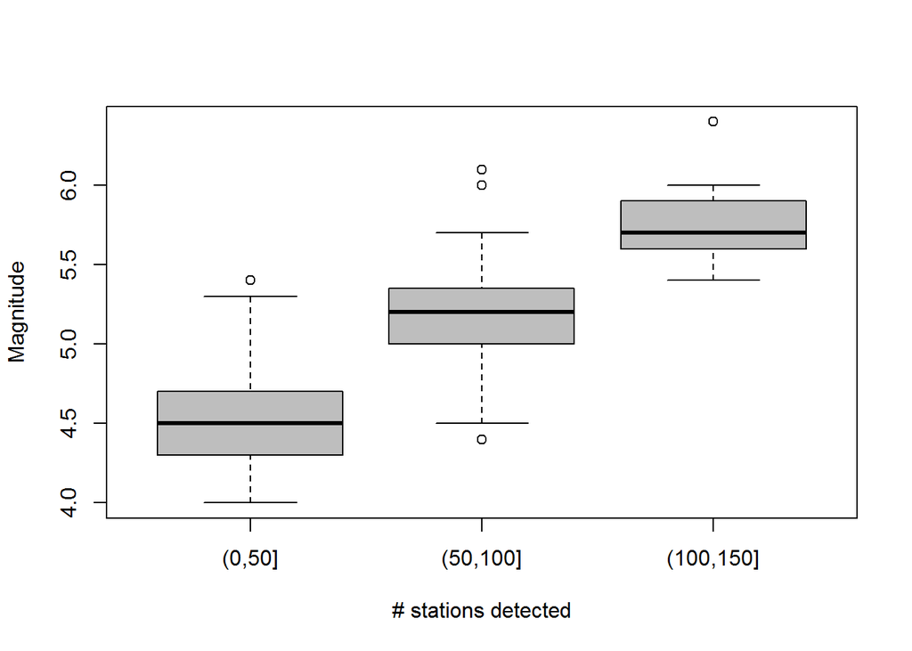

```r
boxplot(quakes$mag~stations.fac, xlab="# stations detected", ylab="Magnitude", col="gray")
```

### Side-by-side boxplots with ggplot2

For ggplot2 the grouping variable `stations.fac` is passed in as the x-axis variable and the magnitude as the y-axis variable. The requirement for a boxplot as specified as the geometry (parameter `geom`).

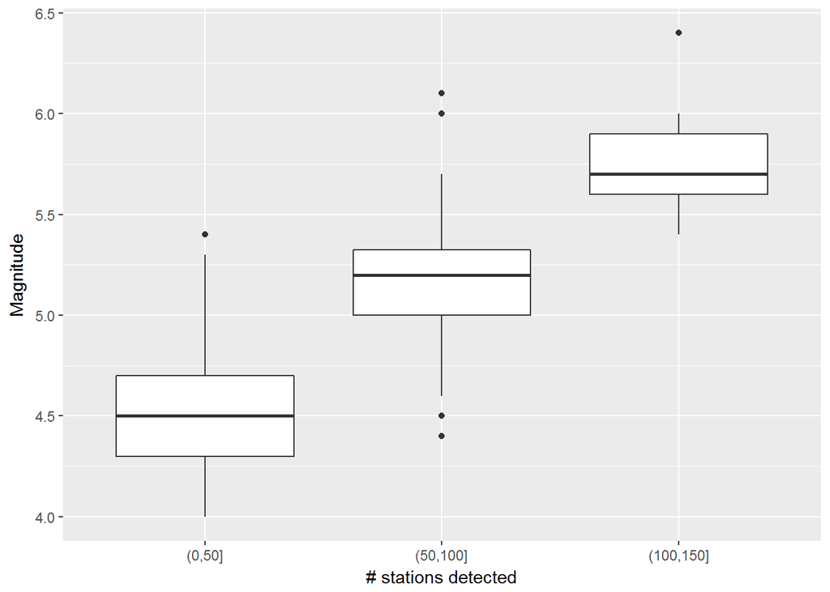

```r
qplot(stations.fac, quakes$mag, geom="boxplot", xlab="# stations detected", ylab="Magnitude")
```

```r
head(iris)
```

```
##   Sepal.Length Sepal.Width Petal.Length Petal.Width Species
## 1          5.1         3.5          1.4         0.2  setosa
## 2          4.9         3.0          1.4         0.2  setosa
## 3          4.7         3.2          1.3         0.2  setosa
## 4          4.6         3.1          1.5         0.2  setosa
## 5          5.0         3.6          1.4         0.2  setosa
## 6          5.4         3.9          1.7         0.4  setosa
```

## Scatterplots

A scatterplot is used to visualise two numeric variables that are **related** in some way. This means that not every plot of points determined by numeric values is in fact a scatterplot.

### Multiple subsets in scatterplot with base R

To display multiple subsets of a dataset in a scatterplot the subsets can be distinguished by the characters and colours used for the points. This can be done using a staged approach with base R.

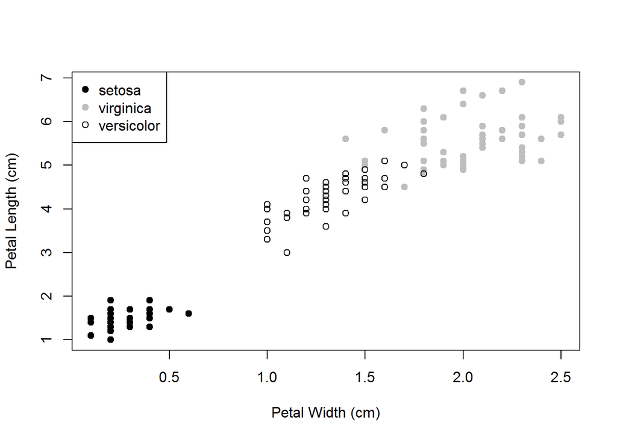

```r
plot(iris[,4], iris[,3], type="n", xlab="Petal Width (cm)", ylab="Petal Length (cm)")
points(iris[iris$Species=="setosa", 4], iris[iris$Species=="setosa", 3], pch=19, col="black")
points(iris[iris$Species=="virginica", 4], iris[iris$Species=="virginica", 3], pch=19, col="gray")
points(iris[iris$Species=="versicolor", 4], iris[iris$Species=="versicolor", 3], pch=1, col="black")
legend("topleft", legend=c("setosa", "virginica", "versicolor"), col=c("black", "gray", "black"), pch=c(19, 19, 1))
```

An alternative is to create vectors that specify the colour and character for each individual point in the set, then using them in a single call to `plot()`.

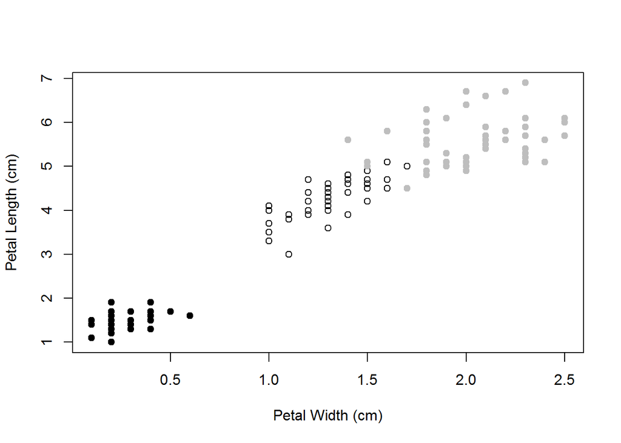

```r
iris_pch <- rep(19, nrow(iris))
iris_pch[iris$Species=="versicolor"] <- 1
iris_col <- rep("black", nrow(iris))
iris_col[iris$Species=="virginica"] <- "gray"

plot(iris[, 4], iris[, 3], col=iris_col, pch=iris_pch, xlab="Petal Width (cm)", ylab="Petal Length (cm)")
```

### Matrix of scatterplots with base R

To display the relationships between more than two variables, a matrix of scatterplots, consisting of a scatterplot for each combination of two variables, can be used (in the code below the vectors `iris_pch` and `iris_col` created in the previous code-chunk are used).

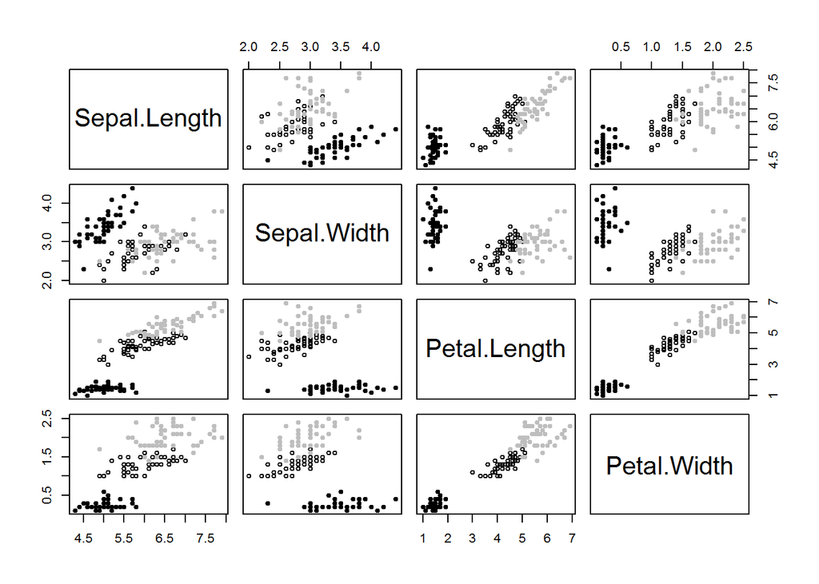

```r
pairs(iris[,1:4], pch=iris_pch, col=iris_col, cex=0.75)
```

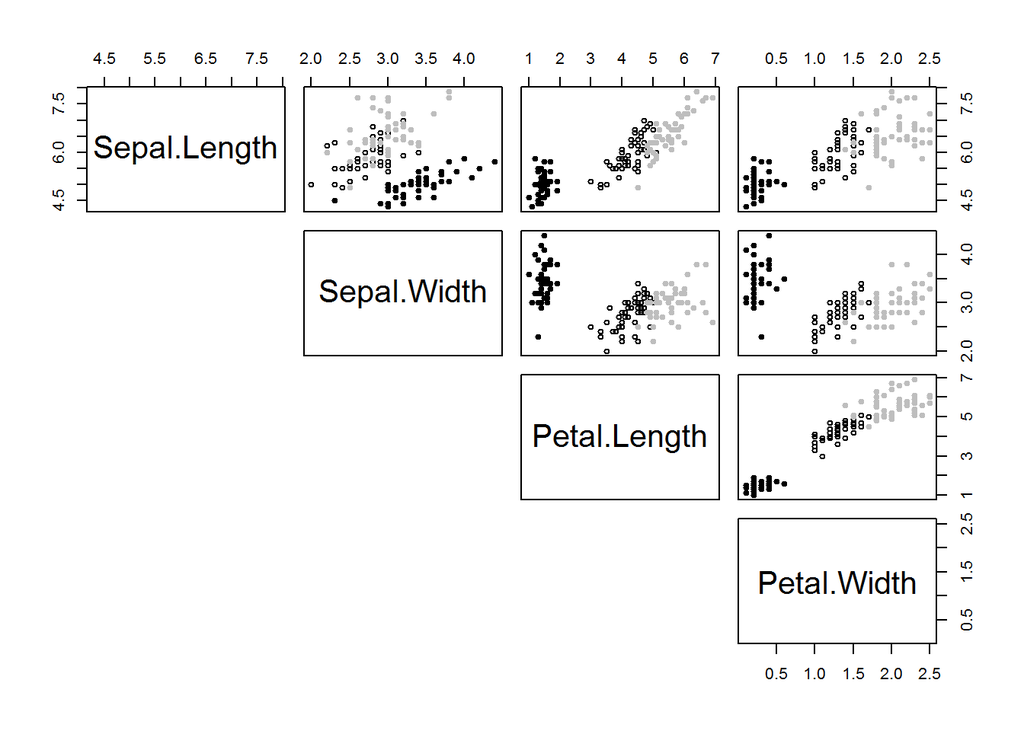

```r
pairs(iris[,1:4], pch=iris_pch, col=iris_col, cex=0.75, lower.panel=NULL)
```

### Multiple subsets in scatterplot with ggplot2

The code to create the same scatterplot earlier plotted with base R is:

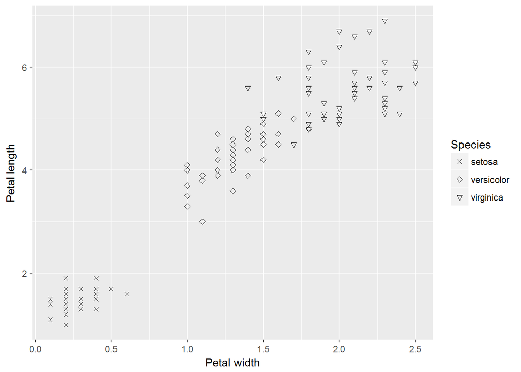

```r
qplot(iris[, 4], iris[, 3], xlab="Petal width", ylab="Petal length", shape=iris$Species) +
   scale_shape_manual(values=4:6) +
   labs(shape="Species")
```

### Matrix of scatterplots with ggplot2

A matrix cannot easily be plotted using only ggplot2 but the GGally package can make it fairly easy.

```r
library(GGally)
```

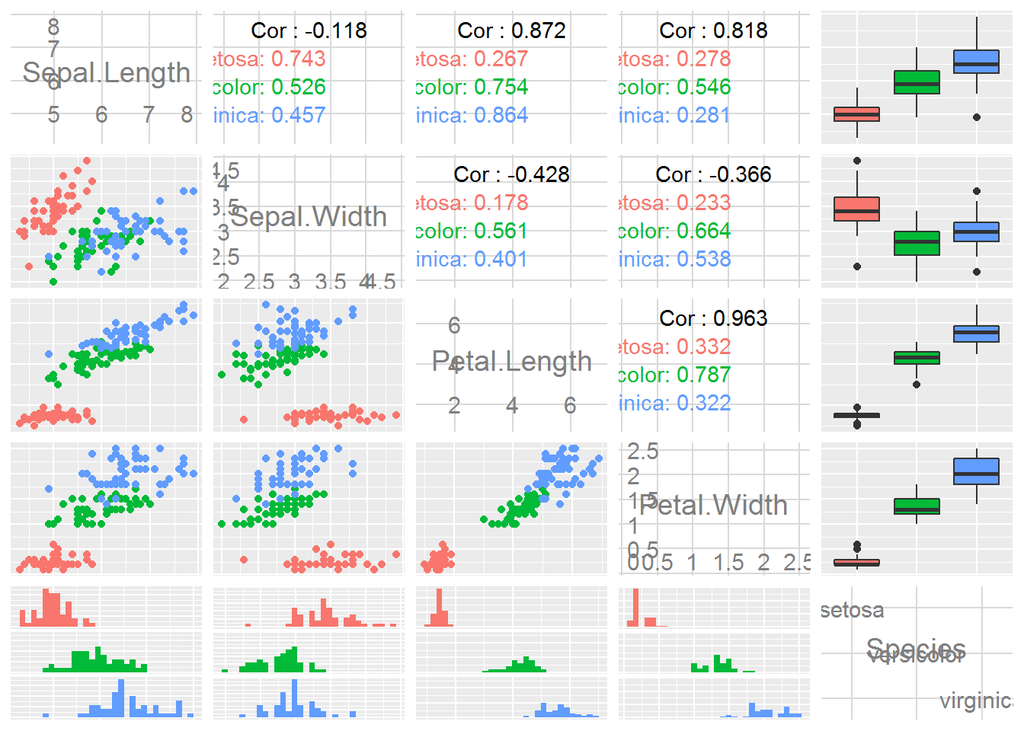

```r
gg<-ggpairs(iris, mapping=aes(col=Species), axisLabels="internal")
print(gg, progress=F)
```

With this package, a complex matrix of graphs can be plotted using a single line of code.

## Exercises

# Advanced visualilsation with base R

## Graphics devices

When the plotting functions used so far are called without any reference to a device, a default plotting device is opened and the plotting function calles applied to it. However, other devices may be opened.

### Opening new devices

- A function that refreshes a plotting window to produce a new image will create a new instance of the active device (the previous content will be lost). The behaviour in RStudio is to preserve previous plots, which can be accessed using the browser ‘back’ button.
- New devices are opened using `dev.new()`
- Only one device can be active at any one time
- The banner title of the active device in R has **[*]** or **(ACTIVE)** appended to it, while in RStudio it is simply the device that is currently being displayed in the Plots window
- A newly opened device becomes the active one by default

As an exercise, close all the graphics devices, then plot stations histogram (cannot be run as a notebook chunk):

`hist(quakes$stations)`

Now create a new device using:

`dev.new()`

The new device’s banner title should have the suffix marking it as active. If you create yet another device in the same way, the new device will be marked active and the previously created one inactive.

Now plot the following:

`plot(quakes$long, quakes$lat)`

The plot should be displayed on the device that was created most recently, as that is the active device.

### Switching between devices

To list the available devices, use the following command:

`dev.list()`

To switch to a different device use the following (the example shows number 3 but you should use the device number corresponding to the first plot made):

`dev.set(3)`

To check that the switch worked, add mean lines to the first plot:

`abline(v=mean(quakes$stations), lty=2)`

### Closing a device

To close a device call (3 is just an example device number):

`dev.off(3)`

As an exercise, close all the devices opened with `dev.new()`.

## Layouts

### Multiple plots on one device

Multiple plots are created by specifying a matrix of ‘canvases’ using the `mfrow` parameter. The following code specifies a matrix of 1 row by 2 columns. As the plots are created, they are placed in sequence in the cells of the matrix. Once the device is ‘full’ a new device is created with the same matrix of canvases etc. untill the mfrow parameter is changed.

```r
dev.new(width=8, height=4)
par(mfrow=c(1, 2))
plot(quakes$long, quakes$lat, cex=0.02*quakes$stations, xlab="Longitude", ylab="Latitude")
hist(quakes$stations)
abline(v=mean(quakes$stations), lty=2)
```

[output not shown]

### Complex layouts

The `layout()` function can be used for the specification of layouts more complex than a straightforward grid.

A matrix is passed into the `layout()` function, which by its dimensions indicates the required dimensions of the grid on the graphics device and by the numeric value in each of its cells indicates the ordinal number of the plot that is to occupy the cell. The `layout()` function initialises the active device or creates a new device if none is opened.

The example below specifies a 2 by 2 grid of cells to be used for plots, with plot 1 and 2 occupying the cells in the first row and plot 3 spanning across the entire bottom row. The `layout.show()` function can be used to see a visual plan of where plots will be placed.

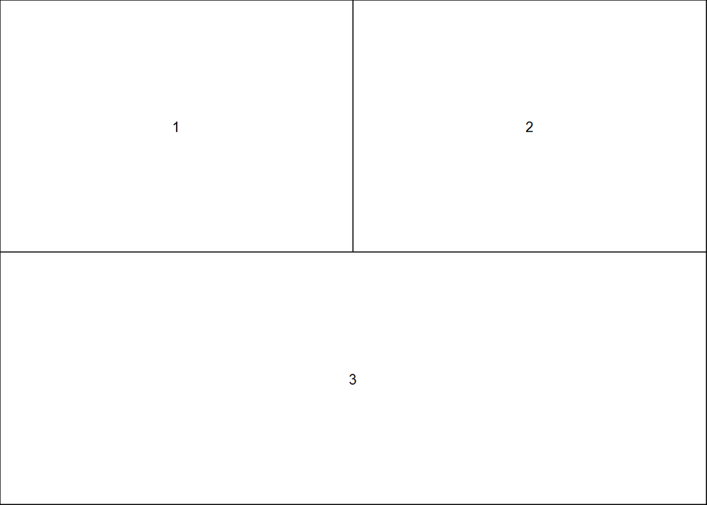

```r
lay.mat <- matrix(c(1, 3, 2, 3), 2, 2)
layout(mat=lay.mat)
layout.show(n=max(lay.mat))
```

Now we use some data provided in the MASS package to create some plots.

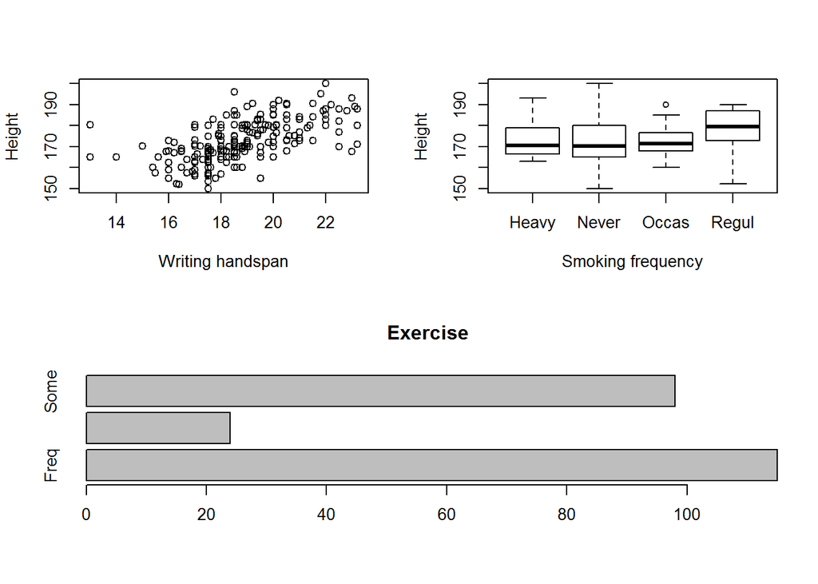

```r
library("MASS")
layout(mat=lay.mat)
plot(survey$Wr.Hnd, survey$Height, xlab="Writing handspan", ylab="Height")
boxplot(survey$Height~survey$Smoke, xlab="Smoking frequency", ylab="Height")
barplot(table(survey$Exer), horiz=TRUE, main="Exercise")
```

The `layout()` function also allows the specification of relative widths and heights, further increasing the flexibility in laying out multiple plots. The only disadvantage of this method is that it does not allow returning to a plot once subsequent ones have been started. This means that data processing and preparation all needs to be completed before this kind of complex plot is created.

## Working with regions and margins

There are three regions in an R plot:

- plot region - the space including the plot itself
- figure region - the space including the plot and the space around it for axes labels and text
- outer region - additional space around the figure region (not included by default but can be added as space around the figure region)

The size of the margins and outer margins (the additional space in the figure and outer regions over the plot and figure regions, respectively) are specified, like the `mfrow` parameter, in a call to `par()` before any drawing begins.

The default margins can be found using the following calls:

```r
par()$oma
```

```
## [1] 0 0 0 0
```

```r
par()$mar
```

```
## [1] 5.1 4.1 4.1 2.1
```

The results are in units called ‘lines’, representing the height of a single line of text.

A simple plot can be used to illustrate this. The call to `box()` plots a box around the specified region, in the case of the example below the **figure region**.

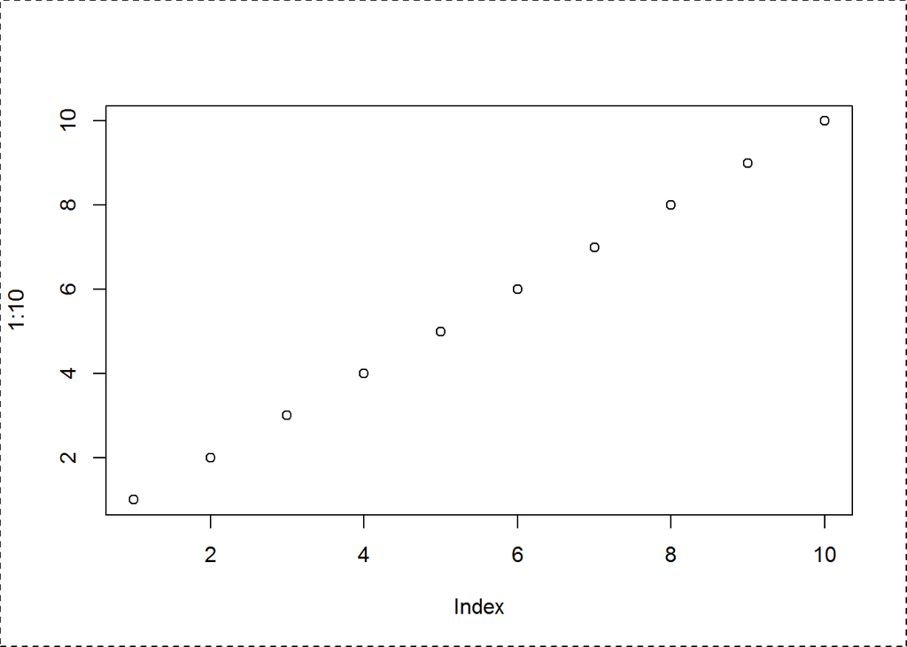

```r
plot(1:10)
box(which="figure", lty=2)
```

Custom margins can be used instead, as in the following example. The `mtext()` function is used to print text in the plot, with the parameter `outer` specifying whether the text should be in the outer or figure region margins (the default is `outer=FALSE`, placing the text in the figure region margins). The parameter `line` is used to position the text relative to the region, in lines.

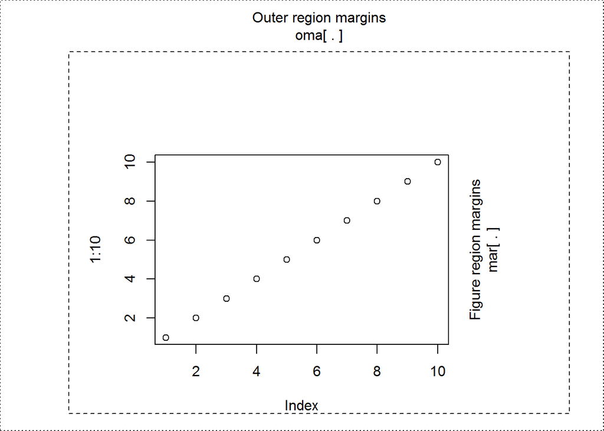

```r
par(oma=c(1, 4, 3, 2), mar=4:7)
plot(1:10)
box("figure", lty=2)
box("outer", lty=3)
mtext("Figure region margins\nmar[ . ]", line=2, side=4)
mtext("Outer region margins\noma[ . ]", line=0.5, outer=TRUE)
```

The parameter `xpd` is used to specify if drawing to the plot should be clipped to the plot region. In some cases it is useful to be able to add elements to the plot that extend into the margin space. An example is in the following code chunk.

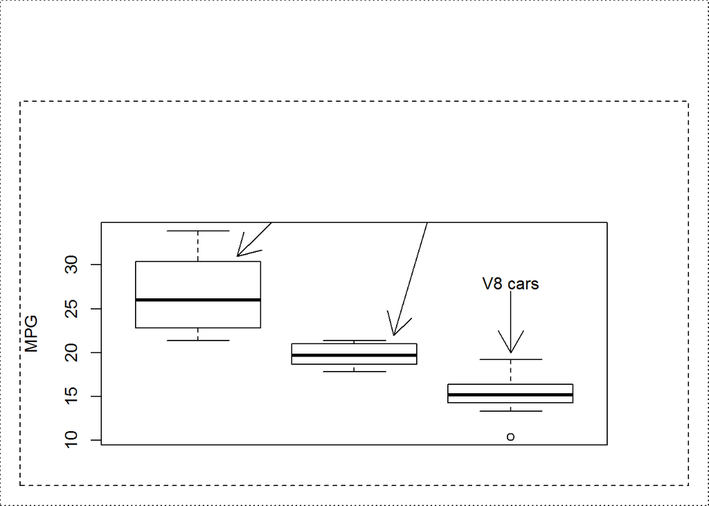

```r
par(oma=c(1, 1, 5, 1), mar=c(2, 4, 6, 4))
boxplot(mtcars$mpg~mtcars$cyl, xaxt="n", ylab="MPG")
box("figure", lty=2)
box("outer", lty=3)
arrows(x0=c(2, 2.5, 3), y0=c(44, 37, 27), x1=c(1.25, 2.25, 3), y1=c(31, 22, 20), xpd=FALSE)
text(x=c(2, 2.5, 3), y=c(45, 38, 28), c("V4 cars", "V6 cars", "V8 cars"), xpd=FALSE)
```

We would really like to see all the arrows in their entirety and to be able to read the associated text. This is achieved by passing in the value TRUE for `xpd`. The last line in the following chunk of code shows the use of the `srt` parameter, with which the rotation angle of a string can be specified. As `mtext()` does not have this parameter, using a combination of `srt` and `xpd=TRUE` is the only way of displaying slanted text in the margins of a plot.

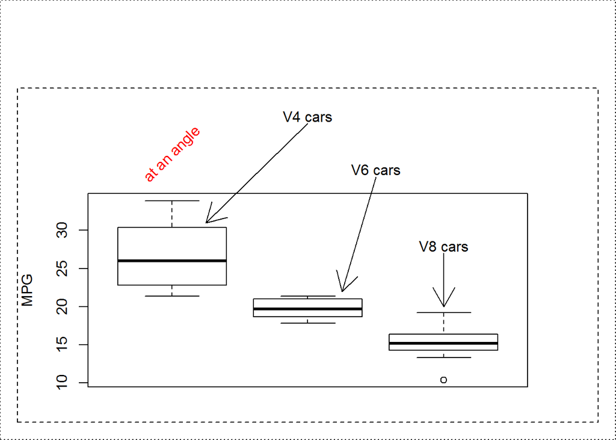

```r
par(oma=c(1, 1, 5, 1), mar=c(2, 4, 6, 4))
boxplot(mtcars$mpg~mtcars$cyl, xaxt="n", ylab="MPG")
box("figure", lty=2)
box("outer", lty=3)
arrows(x0=c(2, 2.5, 3), y0=c(44, 37, 27), x1=c(1.25, 2.25, 3), y1=c(31, 22, 20), xpd=TRUE)
text(x=c(2, 2.5, 3), y=c(45, 38, 28), c("V4 cars", "V6 cars", "V8 cars"), xpd=TRUE)
text(x=1, y=40, labels="at an angle", col="red", srt=45, xpd=TRUE)
```

## Interactive reading of coordinates

To interactively determine coordinates of points in your plot, use `locator()` after creating a plot. This will not work within the notebook. Try it from the console. After calling `locator()` you will be able to click on the points in the plot for which you wish to determine the coordinates. Depending on the R environment, a right-click or ESC key will stop the process.

The `locator()` function can be used for ad-hoc annotation, for example for placing a legend in a plot or just drawing a line. The parameter `n` specifies the number of points to be read.

## Customising plots

There are many parameters in R that can be used for customising plots. One way to use these is to start with a barebones plot that does not have any detail and then add the details in stages.

A default plot example:

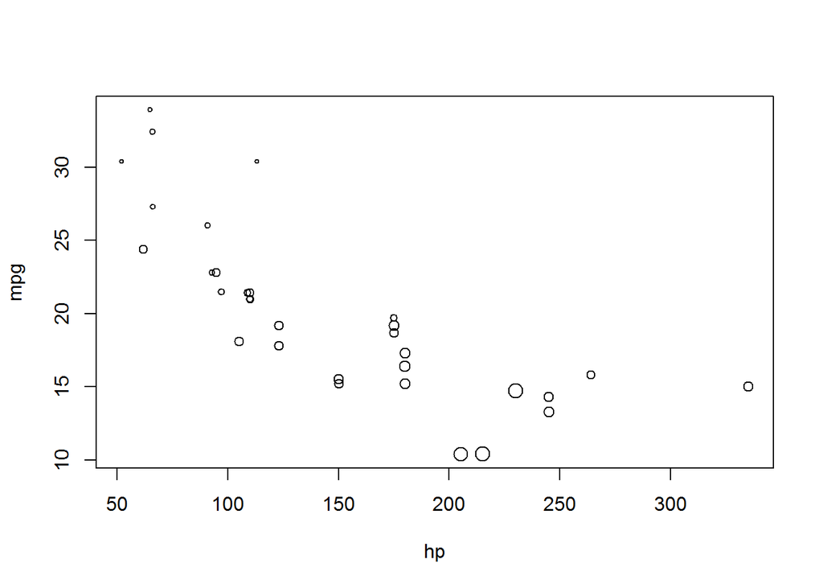

```r
hp<-mtcars$hp
mpg<-mtcars$mpg
# we set the point scaling factors to be proportional to the weight of the vehicle
wtcex<-mtcars$wt/mean(mtcars$wt)
plot(hp, mpg, cex=wtcex)
```

### Suppressing details

The same plot with the extra space around the end points removed, using the parameters `xaxs` and `yaxs`:

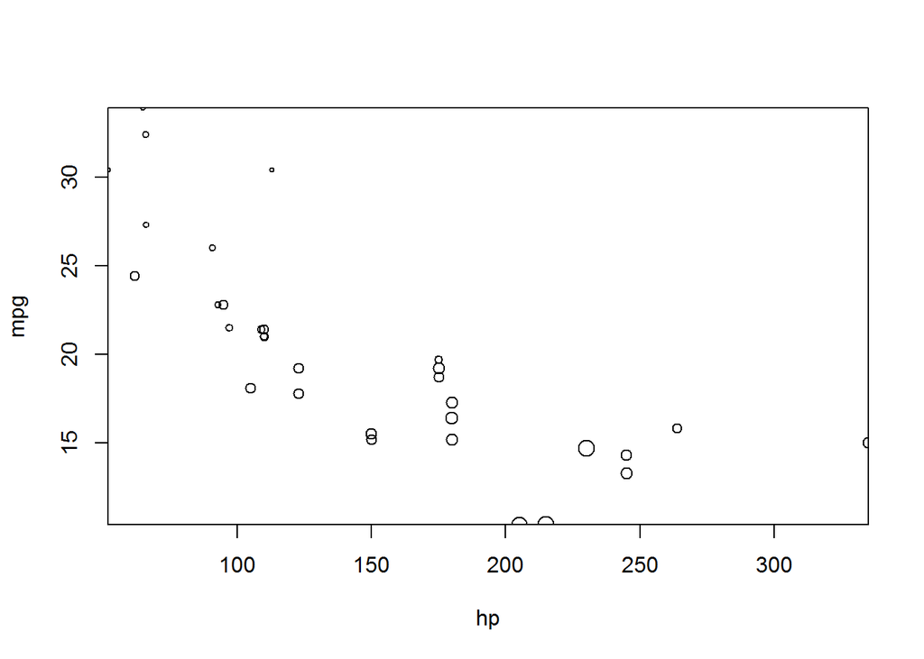

```r
# the default for xaxs and yaxs is "r", which produces some space around the most extreme points
plot(hp, mpg, cex=wtcex, xaxs="i", yaxs="i")
```

There are two ways to produce a ‘barebones’ plot. The first way is to specify type ‘none’ for the axes, labels and box.

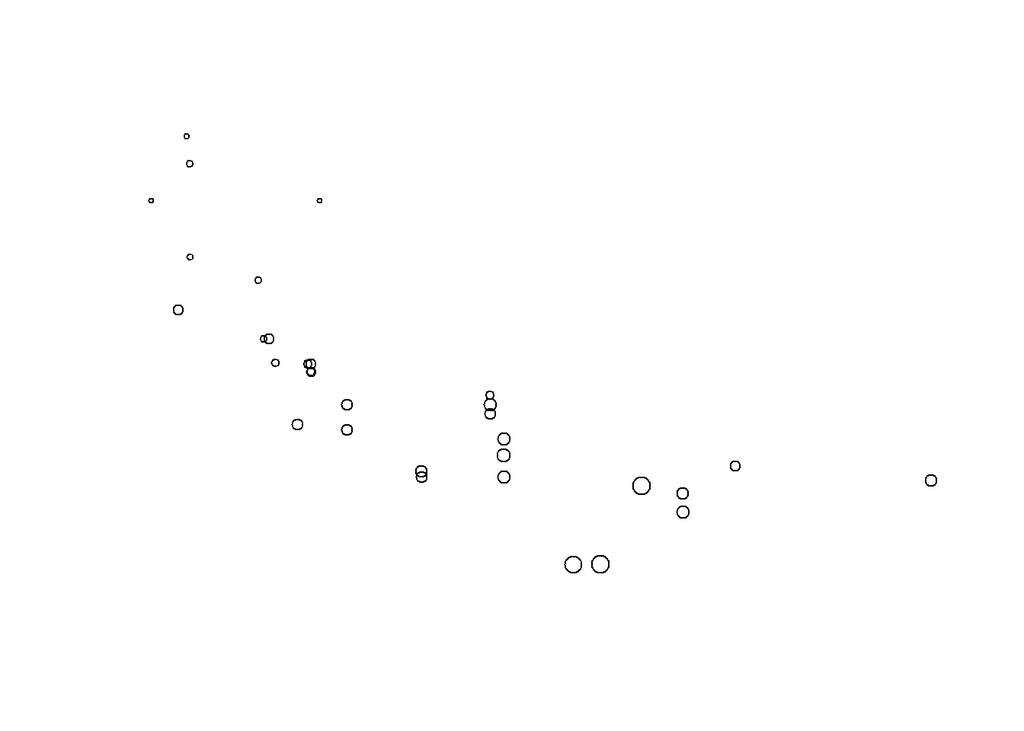

```r
plot(hp, mpg, cex=wtcex, xaxt="n", yaxt="n", bty="n", xlab="", ylab="")
```

The second is to prevent axes and annotations from being included. This method is shorter but does not allow fine-tuning.

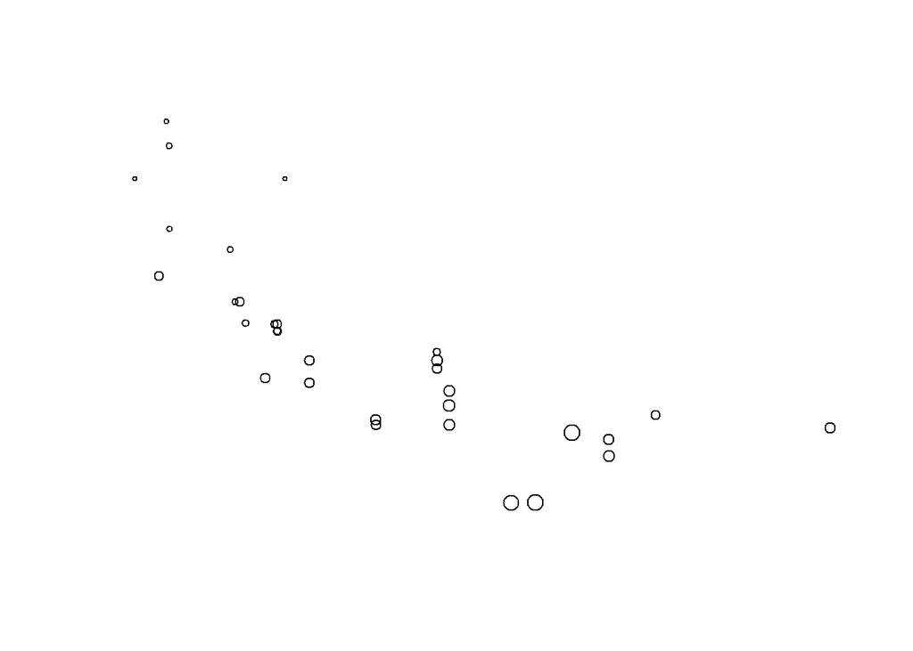

```r
plot(hp, mpg, cex=wtcex, axes=FALSE, ann=FALSE)
```

### Boxes

Boxes are drawn around the plot using `box()` with parameter `bty` indicating the shape. This parameter can take the values ‘o’ (default), “l”, “7”, “c”, “u”, “]” or “n”, with the the sematics of the values contained in their shapes. For example:

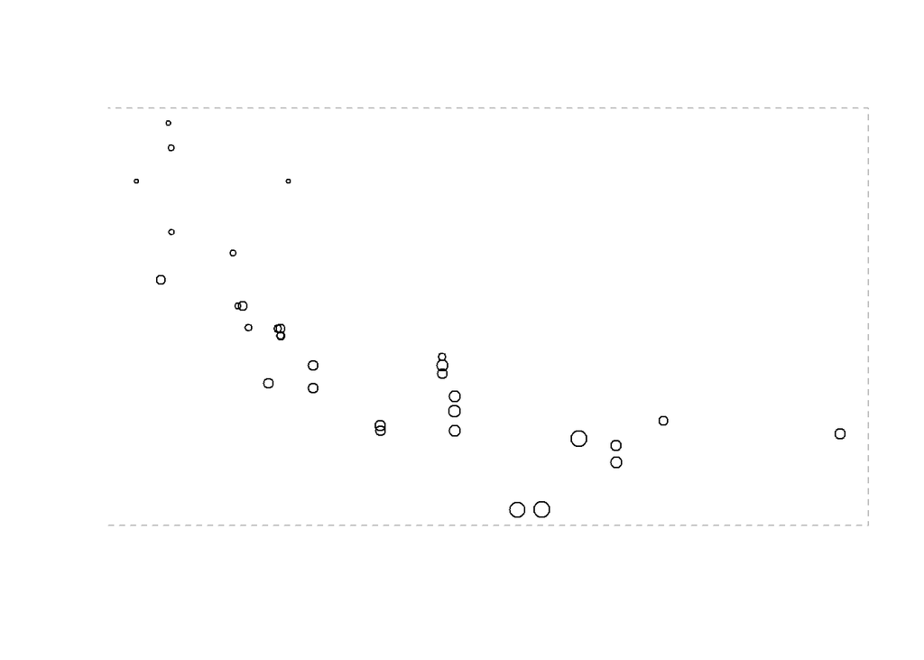

```r
plot(hp, mpg, cex=wtcex, axes=FALSE, ann=FALSE)
box(bty="]", lty=2, col="gray")
```

### Axes

The function `axis()` is used to separately plot an axis. It takes many parameters, some of which are demonstrated in the following examples.

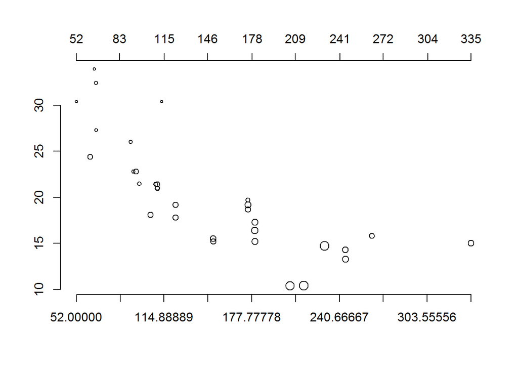

```r
hpseq <- seq(min(hp), max(hp), length=10)
plot(hp, mpg, cex=wtcex, xaxt="n", bty="n", ann=FALSE)
axis(side=1, at=hpseq)
axis(side=3, at=round(hpseq))
```

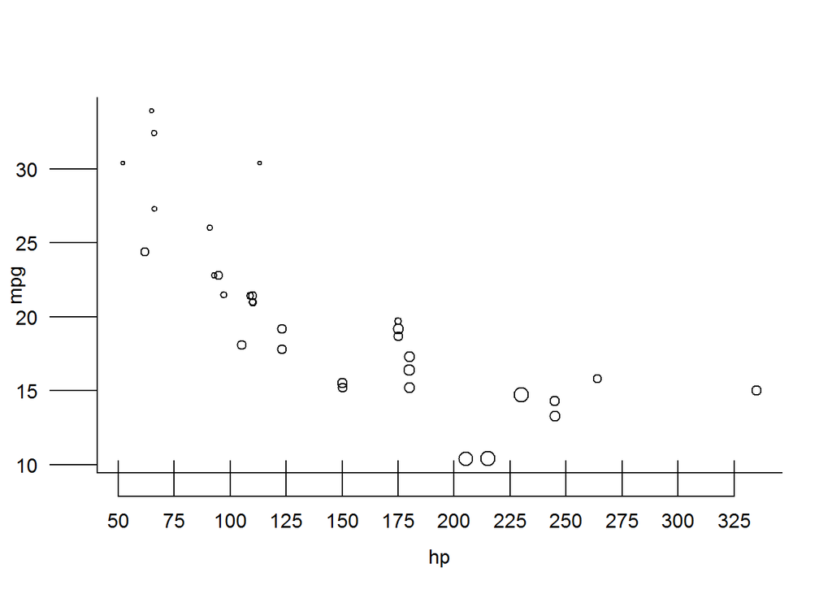

```r
hpseq2 <- seq(50, 325, by=25)
plot(hp, mpg, cex=wtcex, axes=FALSE)
box(bty="l")
axis(side=2, tcl=-2, las=1, mgp=c(3, 2.5, 0))
axis(side=1, at=hpseq2, tcl=1.5, mgp=c(3, 1.5, 1))
```

### Text

Fonts are controlled with two parameters: `family` and `font`. The first one is the specific or generic family, while the second is the face type.

- Generic families that are always available
- Sans
- Serif
- Mono
- Font faces
- 1 - normal
- 2 - bold
- 3 - italic
- 4 - bold and italic

Example of text, using different fonts:

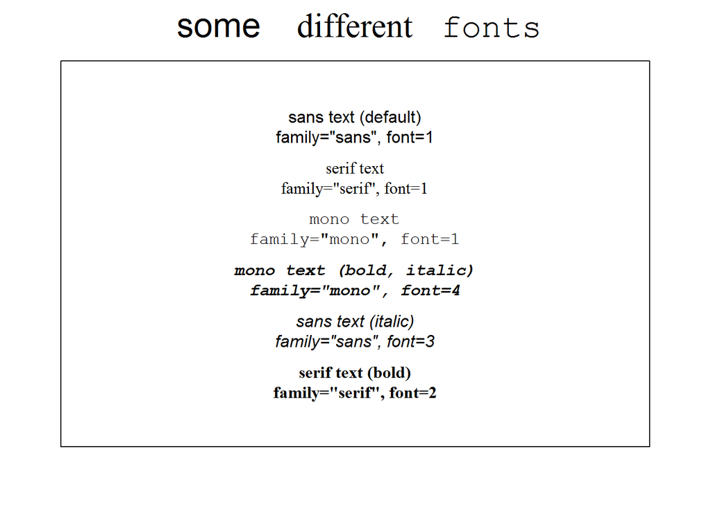

```r
par(mar=c(3, 3, 3, 3))
plot(1, 1, type="n", xlim=c(-1, 1), ylim=c(0, 7), xaxt="n", yaxt="n", ann=FALSE)
text(0, 6, label="sans text (default)\nfamily=\"sans\", font=1")
text(0, 5, label="serif text\nfamily=\"serif\", font=1", family="serif", font=1)
text(0, 4, label="mono text\nfamily=\"mono\", font=1", family="mono", font=1)
text(0, 3, label="mono text (bold, italic)\nfamily=\"mono\", font=4", family="mono", font=4)
text(0, 2, label="sans text (italic)\nfamily=\"sans\", font=3", family="sans", font=3)
text(0, 1, label="serif text (bold)\nfamily=\"serif\", font=2", family="serif", font=2)
mtext("some", line=1, at=-0.5, cex=2, family="sans")
mtext("different", line=1, at=0, cex=2, family="serif")
mtext("fonts", line=1, at=0.5, cex=2, family="mono")
```

# Advanced graphics with ggplot2

## Comparing `qplot()` and `ggplot()`

Difference between `qplot()` and `ggplot`.

- `qplot()` emulates the base R `plot()` function, providing a one-step quick way of creating a plot
- required data: vectors
- `ggplot()` in itself does not create a plot but requires calls to additional functions, but provides more power and flexibility in the building of plots
- required data: data frame

To compare the two, we look at an earlier example produced with `qplot()`, this time using `ggplot()`.

Using `qplot()`:

```r
qplot(mtcars$hp, geom="blank", main="Horsepower", xlab="HP") +
      geom_histogram(color="black", fill="white", breaks=seq(0, 400, 25), closed="right") +
      geom_vline(mapping=aes(xintercept=c(mean(mtcars$hp), median(mtcars$hp)), linetype=factor(c("mean", "median"))), show.legend=TRUE) +
      scale_linetype_manual(values=c(2, 3)) + labs(linetype="")
```

[output not shown]

Using `ggplot()`:

```r
gg.static <- ggplot(data=mtcars, mapping=aes(x=hp)) + ggtitle("Horsepower") + labs(x="HP")
mtcars.mm <- data.frame(mm=c(mean(mtcars$hp), median(mtcars$hp)), stats=factor(c("mean", "median")))
gg.lines <- geom_vline(mapping=aes(xintercept=mm, linetype=stats), show.legend=TRUE, data=mtcars.mm)
gg.static + geom_histogram(color="black", fill="white", breaks=seq(0, 400, 25), closed="right") +
  gg.lines + scale_linetype_manual(values=c(2, 3)) + labs(linetype="")
```

[output not shown]